# representacion gráfica con plot

juan haro

2024-04-29

## Graficos con la función `plot`

- **plot(x,y)**: para dibujar un gráfico básico de puntos siendo $x,y$ vectores numéricos
  - **plot(x)**=**plot(1:length(x),)** si solo damos el vector x funcionará , pero en la coordenada x pondr’desde 1 hasta la longitud del vector y en la coordenada y pondra la x
- **plot(x,function)**: para dibujar el gráfico de una función

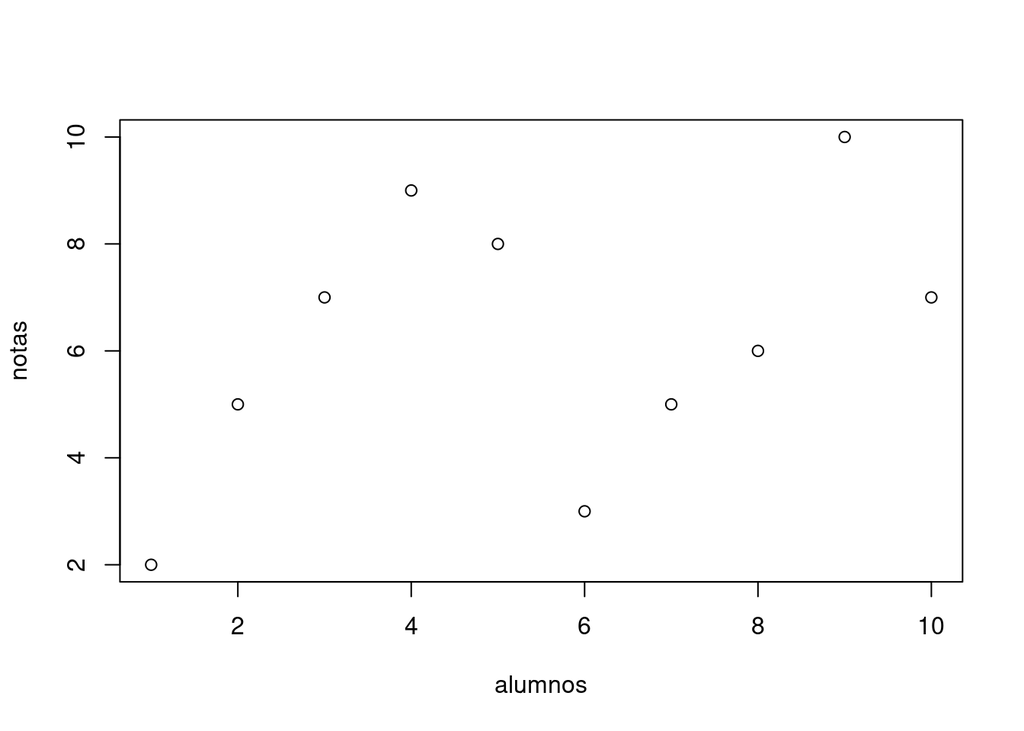

notas alumnos

```r
alumnos =c(1:10)
notas = c(2,5,7,9,8,3,5,6,10,7)
plot(alumnos,notas)
```

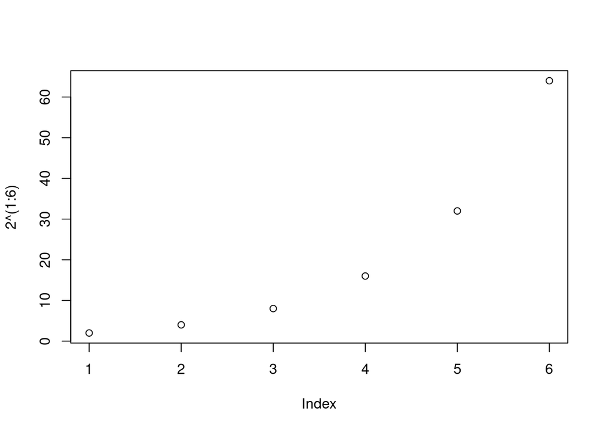

```r
plot(2^(1:6) )
```

arriba el vector x o el eje x lo formará la secuencia 1:6 y el vector o eje y lo hará la función 2^ (1:6)

Si queremos representar una función $f(x)$:

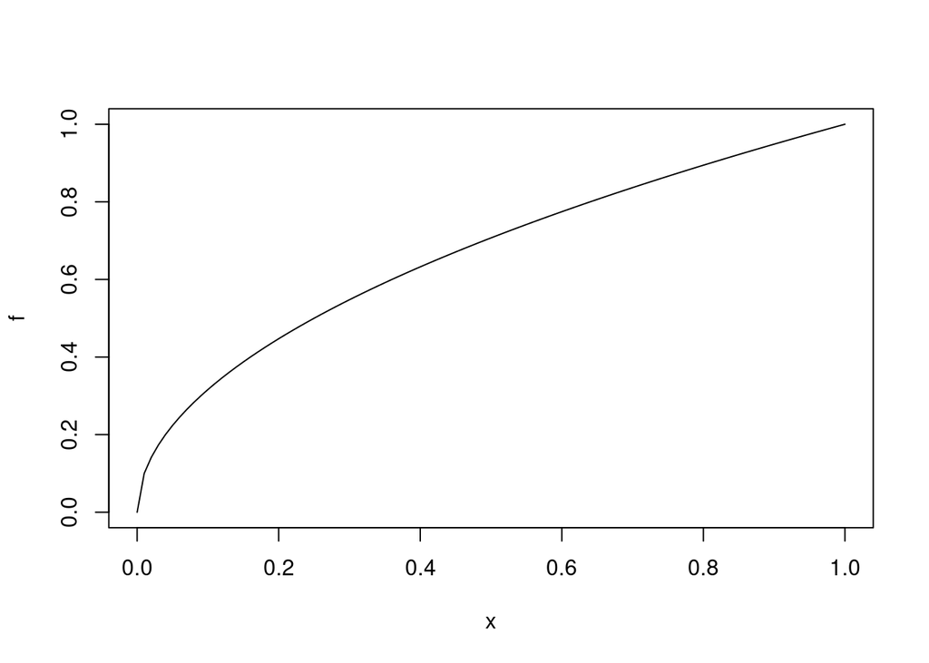

```r
f <- function(x){sqrt(x)}
plot(f)
```

### Parámetros de la función plot()

- **log**: para indica quie queremos el gráfico en escala logaritmica
- **main(“titulo”)**: para poner título al gráfico. Si en vez de un texto queráis poner una expresiónmatematica, tenéis que utilizar la función **expression()** que es una especie de Latex
- **xlab(“etiqueta”)**:para poner etiqueta al eje *X*
- **ylab(“etiqueta”)**: para poner etiqueta al eje *Y*
- **pch=n**(point characer): para elegir el símbolo de los puntos $n=0,1,\ldots ,25.$. El valor por defecto es **pch = 1**
- **cex**: para elegir el tamaño de los símbolos, cex = 1 es el tamaño del símbolo , cex = 2 es el doble de tamaño , cex = 0.5 es la mitad del tamaño original
- **col=“color en ingles”**: para elegir el color de los símbolos [colores en R](http://www.stat.columbia.edu/~tzheng/files/Rcolor.pdf)

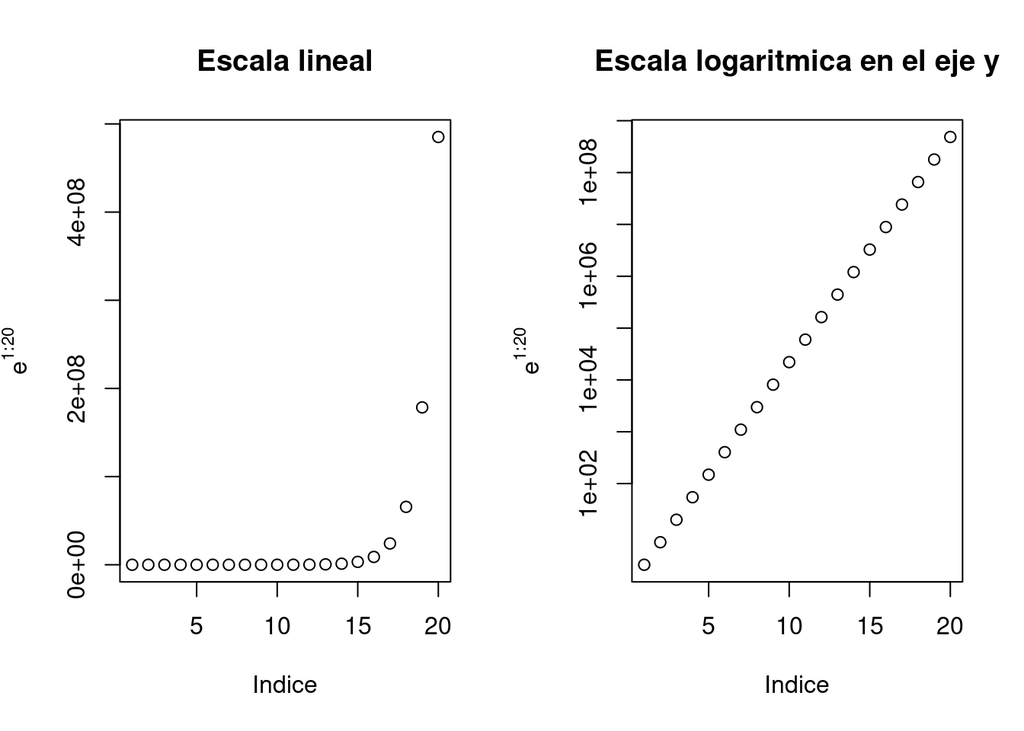

```r
par(mfrow=c(1,2)) # par(mfrow=c(1,2)) indica que quiero ditribuir dos graficos
# en una fila y dos columnas
plot = plot(exp(1:20),xlab = "Indice", ylab = expression(e^{1:20}), main = "Escala lineal")

plotLog = plot(exp(1:20),log = "y",xlab = "Indice",ylab = expression(e^{1:20}),main = "Escala logaritmica en el eje y")
```

#### parámetros

```r
n = 1:20
fib = (1/sqrt(5))*((1+sqrt(5))/2)^n-(1/sqrt(5))*((1-sqrt(5))/2)^n
fib
```

```
##  [1]    1    1    2    3    5    8   13   21   34   55   89  144  233  377  610
## [16]  987 1597 2584 4181 6765
```

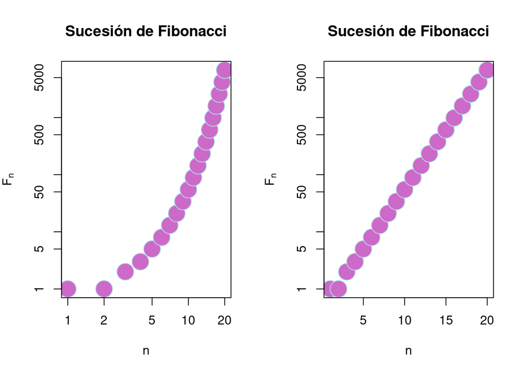

```r
par(mfrow=c(1,2))
plot(fib, xlab="n", ylab = expression(F[n]),main = "Sucesión de Fibonacci",pch=21,cex=3,col="powderblue", bg="orchid3", log = "xy")
# log = "xy" escala logaritmica en x e y
# con el cex=21 y con el parametro col lo que cambia es el color del borde
plot(fib, xlab="n", ylab = expression(F[n]),main = "Sucesión de Fibonacci",pch=21,cex=3,col="powderblue", bg="orchid3", log = "y")
```

```r
par(mfrow=c(1,1))
```

### Parámetros de la función plot()

- **type**: para elegir el tipo de gráfico que queremos:
  - **p**: puntos (valor por defecto)
  - **l**: líneas rectas que unen puntos (dichos puntos no tiene símbolo)
  - **b**(both, lienas y puntos): líneas rectas que unen puntos (dichos puntos tienen símbolo). Las líneas no transpasan los puntos
  - **o**: como el anterior pero en este caso las líneas sí transpasarán los puntos
  - **h**: histograma de líneas
  - **s**: historgrama de escalones
  - **n**: para no dibujar los puntos

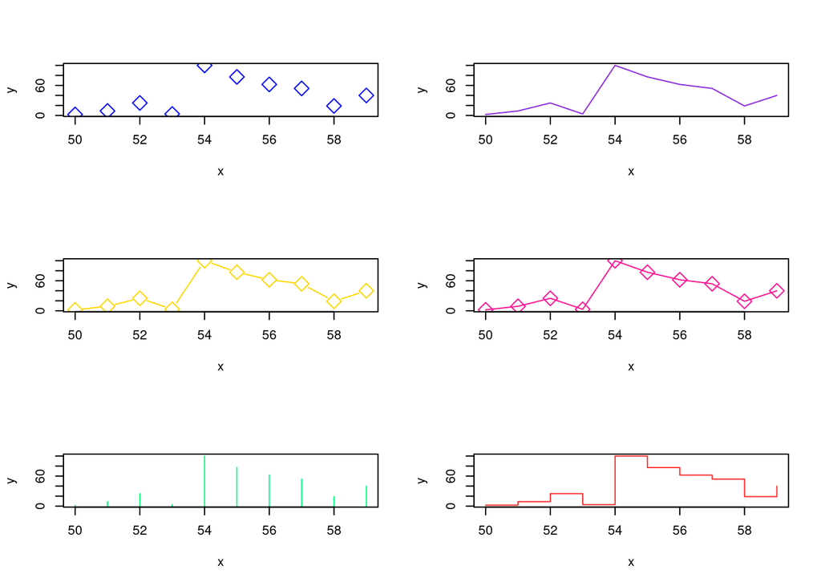

```r
par(mfrow=c(3,2))
x= c(50:59)
y = c(2,9,25,3,100,77,62,54,19,40)
plot(x,y,pch=23, cex = 2 ,col="blue",type= "p")
plot(x,y,pch=23, cex = 2 ,col="blueviolet",type= "l")
plot(x,y,pch=23, cex = 2 ,col="gold",type= "b")
plot(x,y,pch=23, cex = 2 ,col="deeppink",type= "o")
plot(x,y,pch=23, cex = 2 ,col="springgreen",type= "h")
plot(x,y,pch=23, cex = 2 ,col="firebrick1",type= "s")
```

```r
par(mfrow=c(1,1))
```

#### Más Parámetros de la función plot()

- **lty(linetype)**: para especificar el tipo de línea , se puede poner el nombre o el número
  - “solid”:1: línea continua (valor por defecto)
  - “dashed”:2: línea discontinua
  - “dotted”:3: liena de puntos
  - “dotdashed”:4: línea que alterna puntos y rayas
- **lwd(linewidth)**: para especificar el grsos de las líneas
- **xlim(xlimit)**: para modificar el rango del eje *X* se pasa con un vector
- **ylim(ylimit)**: para modificar el rango del eje *Y*
- **xaxp**: para modificar posiciones de las marcas en el eje *X* c(a,b,número de divisiones)
- **yaxp**: para modificar posiciones de las marcas en el eje *Y*

```r
#x= (2*(1:10))
#y= (-1)^(1:20)*5*(1:20)
#plot(x,y,main = "Ejemplo de gráfico", pch=8,cex=1,type = "b", #lty=4,lwd=4,xaxp=c(0,40,2),yaxp=c(-5,100,8))
```

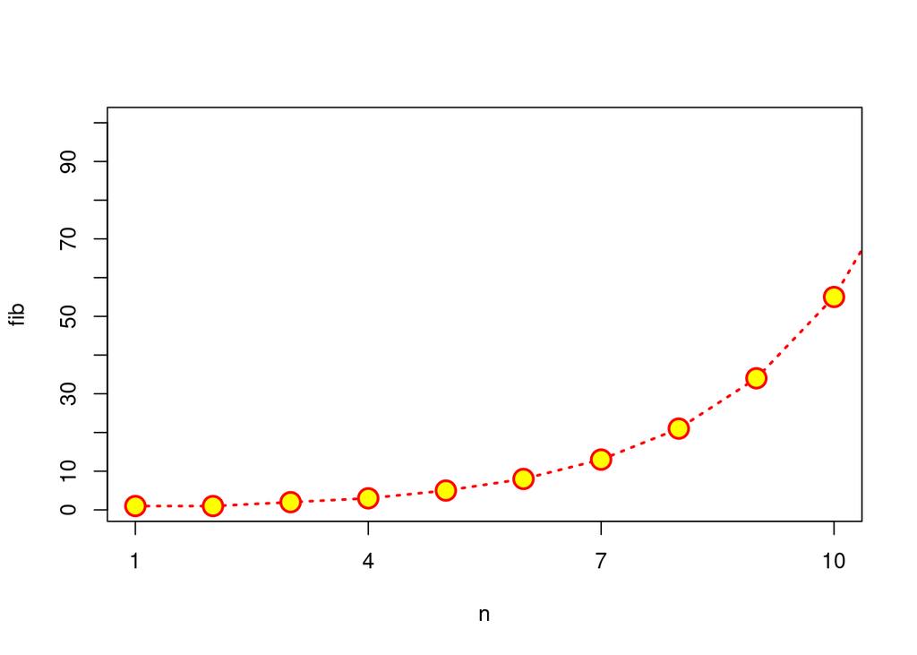

```r
plot(n,fib,pch=21,col="red",bg="yellow", cex=2, type = "o",lty="dotted", lwd=2,xlim = c(1,10),ylim = c(1,100),xaxp=c(1,10,3),yaxp=c(0,100,10))
```

para consultar la documentacion de la función plot ?plot y para colocar los graficos consultar con ?par (parametros)

### Añadir elementos al gráfico

cuando se añade algo encima de un gráfico ya existente , ya no se puede modificar ese gráfico como por ejemplo el rango de coodenadas, las etiquetas el título etc.

- **points(x,y)**: añade un punto de coordenadas $(x,y)$ a un gráfico ya existente
  - tambien podemos utilizar **point** para añadir una familia de puntos
- **abline(a,b line)**: para añadir una recta a un gráfico ya existente, como por ejemplo añadir una recta de regresión lineal
  - **abline(a,b)**: añade la recta $y=bx+a$
  - **abline(v = x0)**: añade la recta vertical $x=x_0\cdot \nu$ puede estar asignado a un vector
  - **abline(h = y0)**: añade la recta horizontal $y=y_0\cdot h$ puede estar asignado a un vector

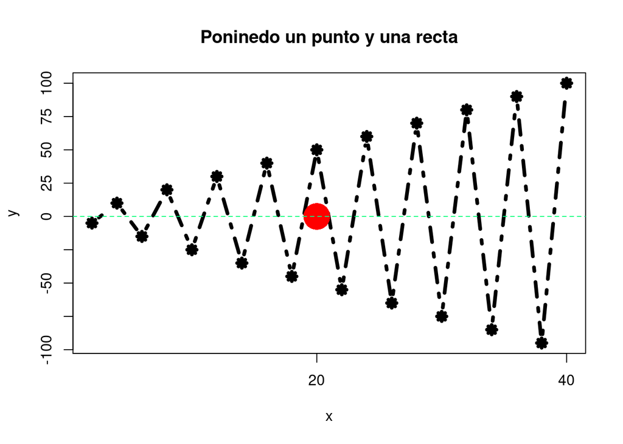

```r
x = 2*(1:20)
y = (-1)^(1:20)*5*(1:20)
plot(x,y,main = "Poninedo un punto y una recta",pch=8, cex=1, type ="b", lty=4,lwd=4
     ,xaxp=c(0,40,2),yaxp=c(-100,100,8))
#fuera del plot se añaden los puntos y las líneas
points(20,0, col="red", cex=4, pch=16)
abline(h=0, lty="dashed", col="springgreen")
```

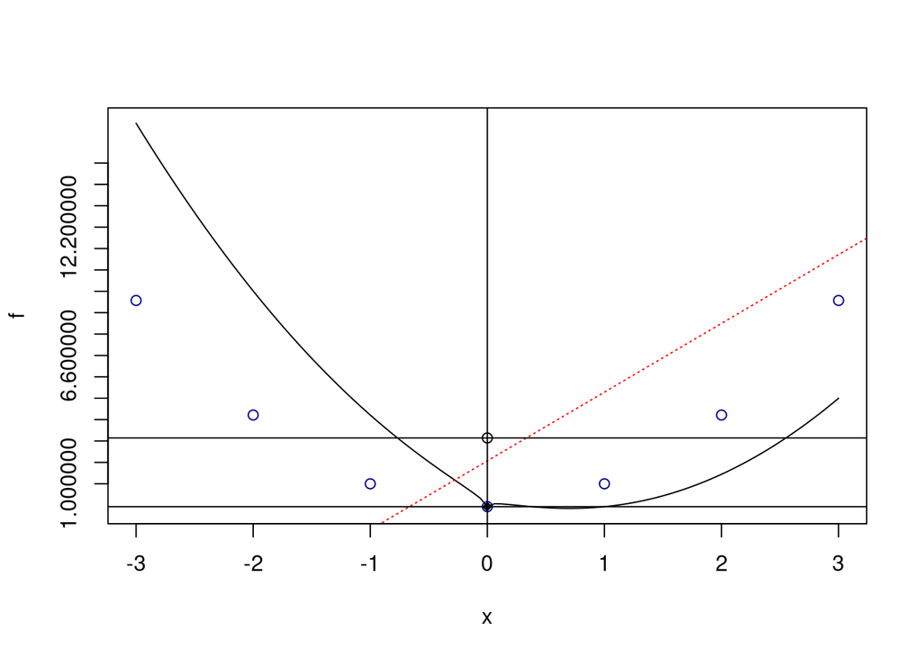

```r
f <- function(x){
  x^2-2*x+sqrt(abs(x))
}
plot(f, xlim=c(-3,3),yaxp=c(1,15,15))
points(0,0, pch=18)
points(-3:3,(-3:3)^2, col="darkblue")
points(0,3)
abline(2,3, lty="dotted", col="red")
abline(h=0)
abline(v=0)
abline(3,0)
```

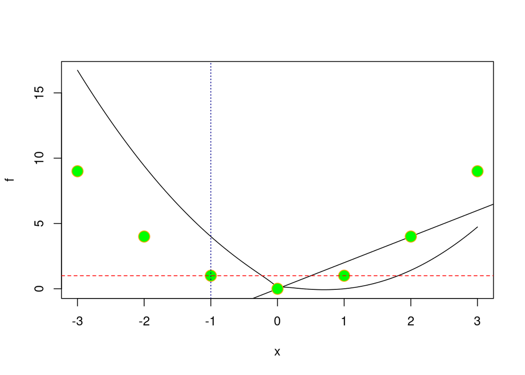

```r
plot(f, xlim = c(-3,3))
abline(0,2)
points(-3:3,(-3:3)^2, pch=21,col="orange",cex=2,bg="green")
abline(v=-1,lty="dotted", col="darkblue")
abline(h=1, lty="dashed",col="red")
```

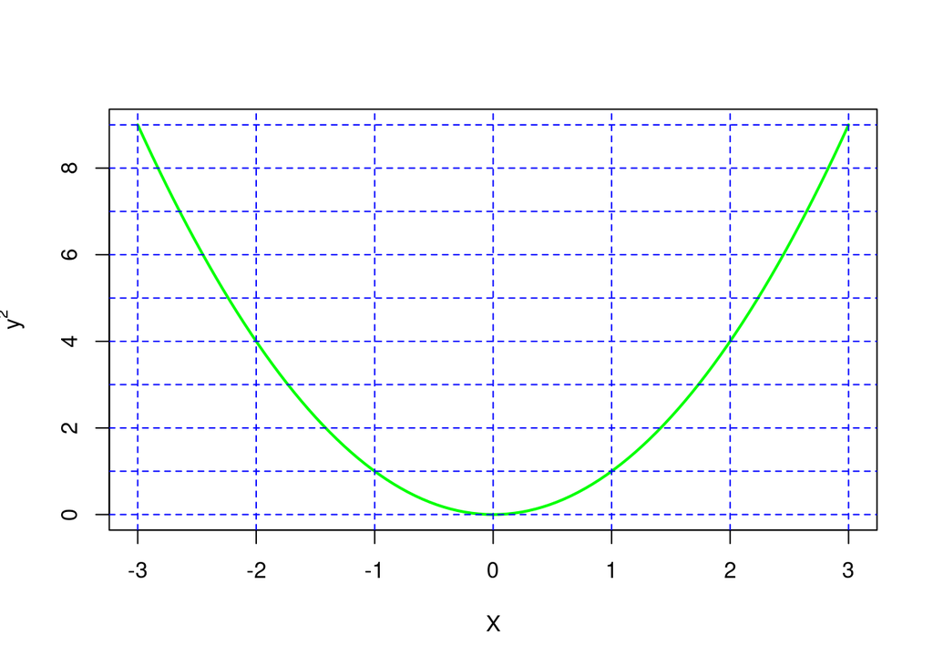

```r
f = function(x){x^2}
plot(f,xlim = c(-3,3),col="green",lwd=2,ylab = expression(y^2), xlab="X")
abline(h=0:9, v=-3:3, lty="dashed",col="blue")
```

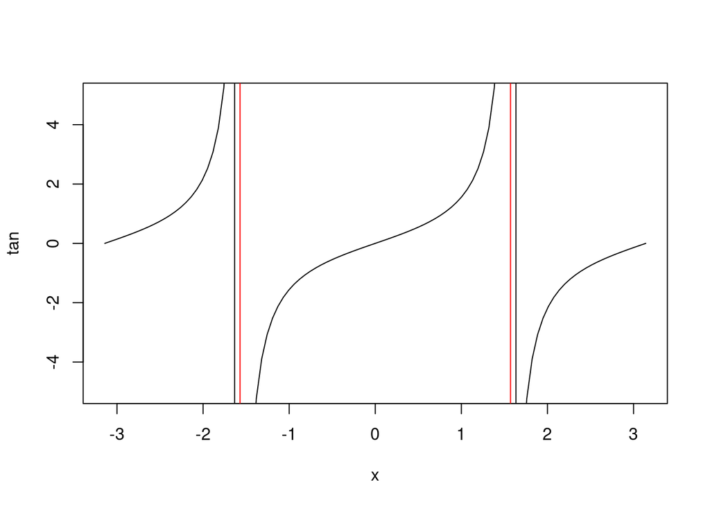

```r
plot(tan,xlim=c(-pi,pi),ylim=c(-5,5))
abline(v=c(-pi/2,pi/2),col="red")
```

### Añadir elementos al gráfico

- **text(x,y,labels=“$\ldots$”)**: añade en el punto de coordenadas $(x,y)$ el texto especificado como argumentos de labels
  - **pos**:permite indicar la posición del texto alrededor de las coodenadas $(x,y)$. Admite los siguientes valores
    - 1:abajo
    - 2: izquierda
    - 3: arriba
    - 4: derecha
    - 5: sin especificar: el texto se situa centrado en el punto $(x,y)$

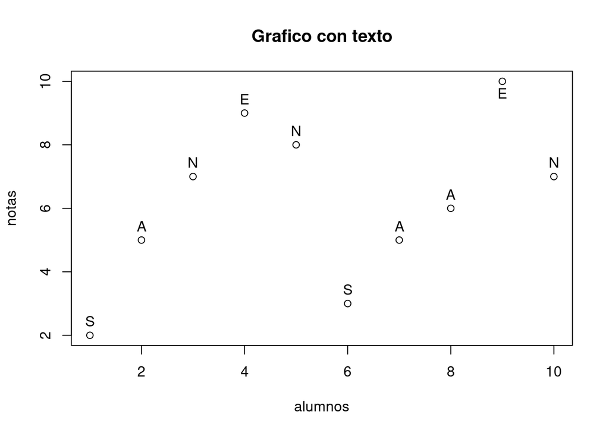

```r
plot(alumnos,notas, main = "Grafico con texto")
text(alumnos,notas,labels = c("S","A","N","E","N","S","A","A","E","N"),pos = c(rep(3,times=8),1,3))
```